# How do environmental factors impact educational attainment in English towns?

Zach, Xinyu, Rishi,

2025-03-07

## Introduction

Our research question below aims to understand how environmental factors impact educational success in english towns:

**What are the strongest environmental predictors of educational success?**

It is very important to understand the relationship between environmental factors at youth, and educational attainment, because doing so allows us to better support the educational success of younger generations. The environmental factors collected in this data set, some of which include location, income, and population density, all contribute to a child’s learning environment. Understanding how these factors correlate, allows us to device strategies that ensure every child has the resources and support needed to succeed academically, and thus have better chances at a comfortable life.

#### Data Source

The data set we chose comes from the UK Office of National Statistics for the purpose of analyzing factors that contribute to children and young people’s higher academic achievements in smaller towns versus larger towns: https://github.com/rfordatascience/tidytuesday/tree/main/data/2024/2024-01-23#english_educationcsv

To gather this data, the sample was selected from pupils who sat their GCSEs in the 2012 to 2013 school year, using Longitudinal Education Outcomes collected by the Department for Education. The data compares educational attainment in English towns at primary school level (Key Stage 2) in the 2007 to 2008 school year, attainment at GSCE level in the 2012 to 2013 school year, qualifications attained by age 18 (school year 2014 to 2015), and qualifications attained by age 22 (school year 2018 to 2019).

#### Worflow

We will be proposing three models for the training split of our english_education data, and then evaluating them on the testing split.

Our response variable will be education_score, which is based on attainment levels of the 2012/13 Key stage 4 cohort. The explanatory variables we will be considering are; key_stage_2_attainment_school_year_2007_to_2008, activity_at_age_19_out_of_work, coastal, level_2_at_age_18, level_3_at_age_18, income_lvl, ttwa_classification, key_stage_4_attainment_school_year_2012_to_2013, and highest_level_qualification_achieved_b_age_22_average_score, which are described in the code book below.

We will be recoding two variables with mutate(), income_flag and ttwa_clasification, to create income_lvl and ttwa_reclass. This way, we can group an individual’s income_flag classification into affluent or non-affluent, and group an individuals travel-to-work area classification into urban or rural.

We will be re-coding income_flag (which is used to describe towns as lower income deprivation, mid income deprivation or higher income deprivation) into income_lvl, in order to simplify observation locations into affluent or non-affluent.

##### Code Book

| variable | class | description |
| --- | --- | --- |
| education_score | numeric | Town/city education score based on attainment levels of the 2012/13 Key stage 4 cohort. |
| activity_at_age_19_out_of_work | numeric | Proportion of the town/city’s 2012/13 key stage 4 cohort claiming out-of-work benefits at age 19. |
| key_stage_2_attainment_school_year_2007_to_2008 | numeric | Proportion of pupils that achieved level 4 or above (expected level) in key stage 2 in English and Maths in the 2007 to 2008 school year. |
| coastal | character | Variable used to describe towns as coastal or non-coastal. |
| level_2_at_age_18 | numeric | Proportion of the town/city’s 2012/13 key stage 4 cohort that achieved level 2 qualifications at 18. |
| level_3_at_age_18 | numeric | Proportion of the town/city’s 2012/13 key stage 4 cohort that achieved level 3 qualifications at 18. |
| income_lvl | character | Mutated column based on income_flag. Classifies neighborhood as affluent or not. |
| income_flag | character | Variable used to describe towns as lower income deprivation, mid income deprivation or higher income deprivation. |
| highest_level_qualification_achieved_b_age_22_average_score | numeric | Town/city highest qualification average score based on highest levels of qualifications achieved of the 2012/13 KS4 cohort. |
| key_stage_4_attainment_school_year_2012_to_2013 | numeric | Proportion of pupils that achieved 5 GCSE or more, including English and Maths, with grades A*-C in the 2012 to 2013 school year. |
| ttwa_classification | character | Travel to work area classification. |
| ttwa_reclass | character | Mutated column based on ttwa_classification. Classifies observation as residing within urban areas or rural. |

## Section 2 - Model Building

### *Model proposed by Zach:*

#### Understanding Variable Relationships: Education Score and Income Level

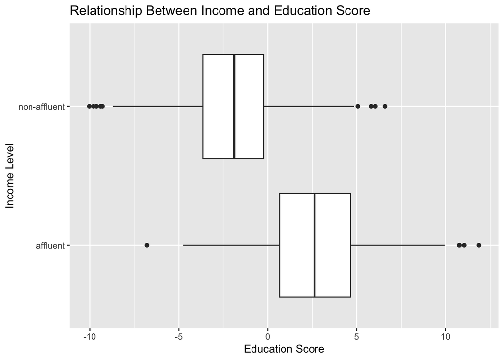

##### Evaluating difference in means

```
## # A tibble: 1 × 2
##   lower upper
##   <dbl> <dbl>
## 1  4.31  5.00
```

#### Understanding Variable Relationships: Education Score and Out of Work Status at 19

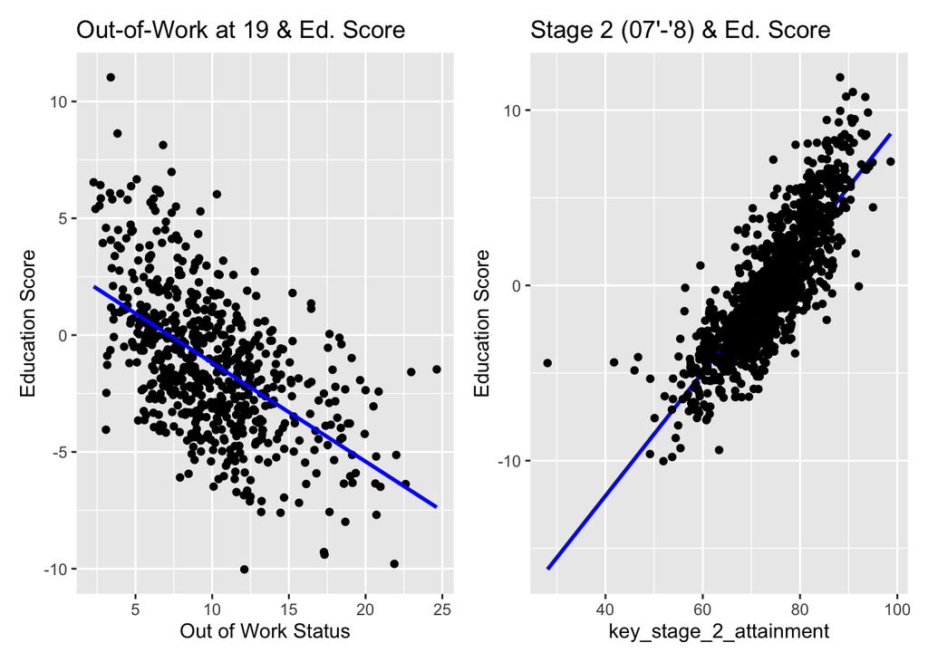

##### Evaluating slopes: Education Score & Out of Work Status at 19

```
## # A tibble: 1 × 2
##    lower  upper
##    <dbl>  <dbl>
## 1 -0.474 -0.371
```

##### Evaluating slopes: Education Score & Stage 2 Attainment (07’ - 08’)

```
## # A tibble: 1 × 2
##   lower upper
##   <dbl> <dbl>
## 1 0.333 0.372
```

### Final Model Evaluation

```
## # A tibble: 4 × 5
##   term                                     estimate std.error statistic  p.value
##   <chr>                                       <dbl>     <dbl>     <dbl>    <dbl>
## 1 (Intercept)                               -19.3      0.979     -19.7  3.03e-57
## 2 activity_at_age_19_out_of_work             -0.165    0.0234     -7.03 1.23e-11
## 3 key_stage_2_attainment_school_year_2007…    0.287    0.0120     23.9  3.30e-73
## 4 income_lvlnon-affluent                     -0.978    0.252      -3.88 1.29e- 4
```

```
## # A tibble: 1 × 1
##   adj.r.squared
##           <dbl>
## 1         0.767
```

```
## # A tibble: 5 × 2
##   education_score .fitted
##             <dbl>   <dbl>
## 1          -1.17   -0.371
## 2          -3.72   -1.89
## 3          -4.06   -5.23
## 4           1.38    2.31
## 5           0.184  -0.788
```

```
## # A tibble: 1 × 3
##   .metric .estimator .estimate
##   <chr>   <chr>          <dbl>
## 1 rmse    standard        1.53
```

For an individual from an affluent household, education_score = -19.2900007 - 0.1648142*activity_at_age_19_out_of_work + 0.2867241*key_stage_2_attainment_school_year_2007_to_2008 For an individual from a non-affluent household, education_score = -19.2900007 - 0.1648142*activity_at_age_19_out_of_work + 0.2867241*key_stage_2_attainment_school_year_2007_to_2008 - 0.9782342

### *Model proposed by Xinyi Gu:*

Xinyu will explore the relationship between education_score as a response variable and coastal as categorical explanatory variable, along with level 2 qualification at age 18, and level 3 qualification at age 18 as continuous explanatory variable.

#### Understanding Variable Relationships: Education Score and Coastal Status

##### Evaluating difference in means

```
## # A tibble: 1 × 2
##   lower upper
##   <dbl> <dbl>
## 1 -2.73 -1.68
```

Coastal towns have significantly lower education scores than non-coastal towns, as shown by a 95% confidence interval of (-2.72804, -1.678062).

#### Understanding Variable Relationships: Education Score and Level 2/3 Attainment at 18

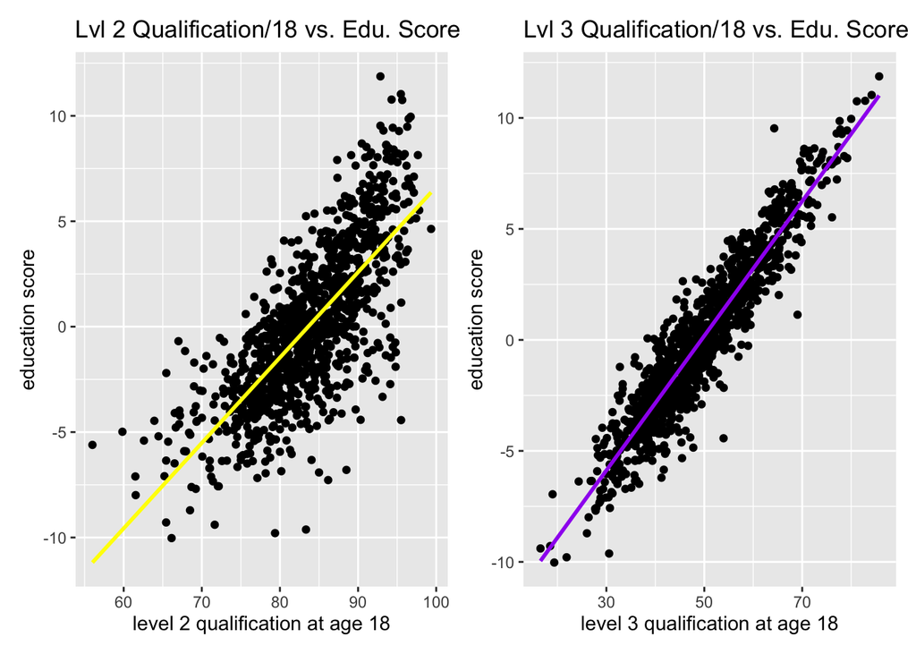

##### Evaluating slopes: Education Score & Level 2 Attainment at 18

```
## # A tibble: 1 × 2
##   lower upper
##   <dbl> <dbl>
## 1 0.382 0.430
```

Education score shows a moderate positive correlation with level_2_at_age_18 (slope: 0.3815474 to 0.430124) and a statistically significant relationship overall, as the confidence intervals exclude 0.

##### Evaluating slopes: Education Score & Level 3 Attainment at 18

```
## # A tibble: 1 × 2
##   lower upper
##   <dbl> <dbl>
## 1 0.297 0.310
```

Education score shows a moderate positive correlation with level_3_at_age_18 (slope: 0.2966233 to 0.3097914). and a statistically significant relationship overall, as the confidence intervals exclude 0.

### Final Model Evaluation

```
## # A tibble: 4 × 5
##   term               estimate std.error statistic   p.value
##   <chr>                 <dbl>     <dbl>     <dbl>     <dbl>
## 1 (Intercept)        -19.9      0.769    -26.0    1.83e- 97
## 2 level_2_at_age_18    0.0740   0.0119     6.24   8.68e- 10
## 3 level_3_at_age_18    0.277    0.00698   39.7    1.95e-163
## 4 coastalNon-coastal   0.0104   0.160      0.0649 9.48e-  1
```

```
## # A tibble: 1 × 1
##   adj.r.squared
##           <dbl>
## 1         0.896
```

```
## # A tibble: 5 × 2
##   education_score .fitted
##             <dbl>   <dbl>
## 1          -1.17   -2.80
## 2          -3.72   -3.95
## 3          -4.06   -2.31
## 4           1.38    0.506
## 5           0.184   0.916
```

```
## # A tibble: 1 × 3
##   .metric .estimator .estimate
##   <chr>   <chr>          <dbl>
## 1 rmse    standard        1.15
```

### *Model proposed by Rishi:*

Rishi is going to be building a Model analyzing the relationships between ‘highest_level_qualification_achieved_b_age_22_average_score’, ‘key_stage_4_attainment_school_year_2012_to_2013’, and ‘education_score’

#### Understanding Variable Relationships: Education Score and Highest Qualification Achieved by 22

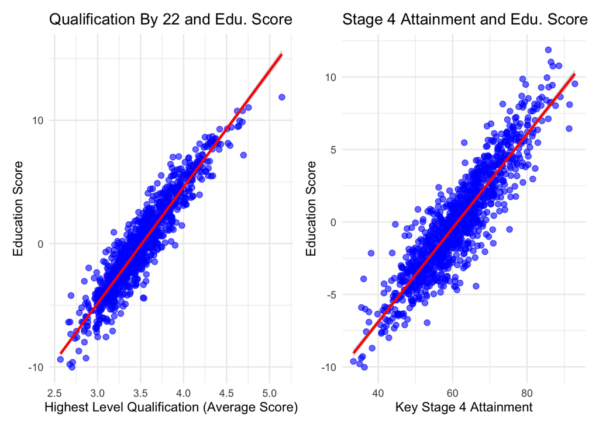

#### Understanding Variable Relationships: Education Score and ttwa Classification

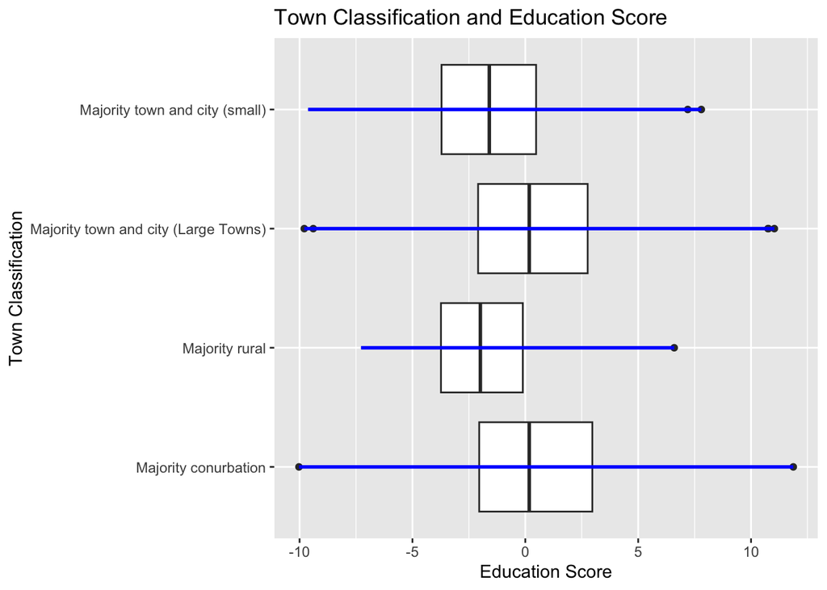

#### Evaluating Difference in Means: Education Score & ttwa Classification

```
## # A tibble: 1 × 2
##   lower upper
##   <dbl> <dbl>
## 1 -2.56 -1.37
```

### Final Model Evaluation

```
## # A tibble: 4 × 5
##   term                                    estimate std.error statistic   p.value
##   <chr>                                      <dbl>     <dbl>     <dbl>     <dbl>
## 1 (Intercept)                              -30.1     0.370      -81.5  1.74e-308
## 2 highest_level_qualification_achieved_b…    5.84    0.166       35.1  3.27e-142
## 3 key_stage_4_attainment_school_year_201…    0.159   0.00589     27.1  5.20e-103
## 4 ttwa_reclassUrban                         -0.164   0.126       -1.30 1.95e-  1
```

```
## # A tibble: 1 × 1
##   adj.r.squared
##           <dbl>
## 1         0.950
```

```
## # A tibble: 5 × 2
##   education_score .fitted
##             <dbl>   <dbl>
## 1          -1.17  -1.76
## 2          -3.72  -4.24
## 3          -4.06  -2.84
## 4           1.38  -0.0274
## 5           0.184  0.401
```

```
## # A tibble: 1 × 3
##   .metric .estimator .estimate
##   <chr>   <chr>          <dbl>
## 1 rmse    standard       0.736
```

Education Score strongly correlates with Highest Level Qualification (Average Score) and Key Stage 4 Attainment, as shown by tightly clustered data points along regression lines with minimal outliers. In addition, the 95% confidence interval comparing the difference in mean education_score between commuting characteristics of urban areas consisting of large towns and conurbations, and rural areas, suggests that there is a statistically significant difference between the two groups. For these reasons, I found these variables impactful on education_score, and relevant to include in my model.

If the individual lives in a rural area, education_score = -30.1462473 +5.8364202*highest_level_qualification_achieved_b_age_22_average_score + 0.1593487*key_stage_4_attainment_school_year_2012_to_2013

#### Predicitive Analysis

| Model | Adjusted R square | RMSE |
| --- | --- | --- |
| `model_zach` | 0.7670164 | 1.534553 |
| `model_finalxinyi` | 0.8959322 | 1.153039 |
| `model_rishi` | 0.9495037 | 0.7361793 |

## Section 3 - Results

```
## # A tibble: 4 × 5
##   term                                    estimate std.error statistic   p.value
##   <chr>                                      <dbl>     <dbl>     <dbl>     <dbl>
## 1 (Intercept)                              -30.4     0.258     -118.   0
## 2 highest_level_qualification_achieved_b…    5.96    0.115       51.6  9.87e-296
## 3 key_stage_4_attainment_school_year_201…    0.155   0.00409     38.0  5.22e-202
## 4 ttwa_reclassUrban                         -0.121   0.0859      -1.41 1.58e-  1
```

Applying Rishi’s model to the full data set tells us that **for an individual residing in a rural area, their education_score = -30.3557907 + 5.9597217*highest_level_qualification_achieved_b_age_22_average_score + 0.1554220*key_stage_4_attainment_school_year_2012_to_2013**.

## Bibliography

Data set:  
R for Data Science Online Learning Community. (2024). Educational Attainment of Young People in English Towns [english_education.csv]. GitHub. Retrieved December 5, 2024, from https://github.com/rfordatascience/tidytuesday/tree/main/data/2024/2024-01-23#english_educationcsv